# DoReCo Rhythms

Lara S. Burchardt

2023-09-12

## DoReCo Rhythms

We analyse the rhythms of the DoReCo languages on two levels: on the IPU level (interpausal Units) and the word level of each language.

The results are presented visually in this Document.

Whenever an ‘ioi beat’ is presented, it is in Hertz. The unbiased CV is the coefficient of variation adjusted for small sample sizes. The CV is the standard deviation divided by the mean.

This is a first attempt of providing helpful visualizations to decide on further analysis or to guide future decisions on what to plot, the plots are to be considered drafts and any feedback is welcome.

## Data Summary

### IPU Level

```
##     ioi_beat        unbiased_cv          npvi        fourier_beat
##  Min.   :0.02641   Min.   :0.2446   Min.   :25.68   Min.   :0.001427
##  1st Qu.:0.35476   1st Qu.:0.4876   1st Qu.:51.38   1st Qu.:1.361071
##  Median :0.41087   Median :0.5535   Median :56.50   Median :2.494266
##  Mean   :0.41241   Mean   :0.6220   Mean   :  Inf   Mean   :2.569390
##  3rd Qu.:0.46793   3rd Qu.:0.6373   3rd Qu.:63.37   3rd Qu.:3.787188
##  Max.   :0.71508   Max.   :7.6502   Max.   :  Inf   Max.   :4.968454
##  NA's   :4         NA's   :4        NA's   :4       NA's   :4
##    n_elements
##  Min.   :   3.0
##  1st Qu.:  38.0
##  Median :  89.0
##  Mean   : 141.4
##  3rd Qu.: 176.5
##  Max.   :1797.0
##  NA's   :4
```

### Word Level

```
##     ioi_beat       unbiased_cv           npvi          fourier_beat
##  Min.   :0.1158   Min.   : 0.4897   Min.   :  6.156   Min.   :0.000703
##  1st Qu.:1.2002   1st Qu.: 0.8553   1st Qu.: 73.390   1st Qu.:0.365741
##  Median :1.5103   Median : 1.0612   Median : 80.205   Median :2.827763
##  Mean   :1.5517   Mean   : 2.1699   Mean   : 80.749   Mean   :2.446824
##  3rd Qu.:1.8064   3rd Qu.: 1.3410   3rd Qu.: 88.299   3rd Qu.:3.950556
##  Max.   :3.5162   Max.   :34.8116   Max.   :115.995   Max.   :4.993038
##  NA's   :2        NA's   :2         NA's   :2         NA's   :2
##    n_elements
##  Min.   :    6.0
##  1st Qu.:  128.0
##  Median :  290.0
##  Mean   :  560.4
##  3rd Qu.:  691.5
##  Max.   :19481.0
##  NA's   :2
```

## Visualizations

The same visualizations are produced for both levels. We plot IOI beat and Coefficient of Variation on the whole dataset, and divided into male and female identifying speakers. Furthermore we show the ioi rhythm for each language and per language family. Histograms of ioi beats and cvs are also shown per level.

### IPU Level

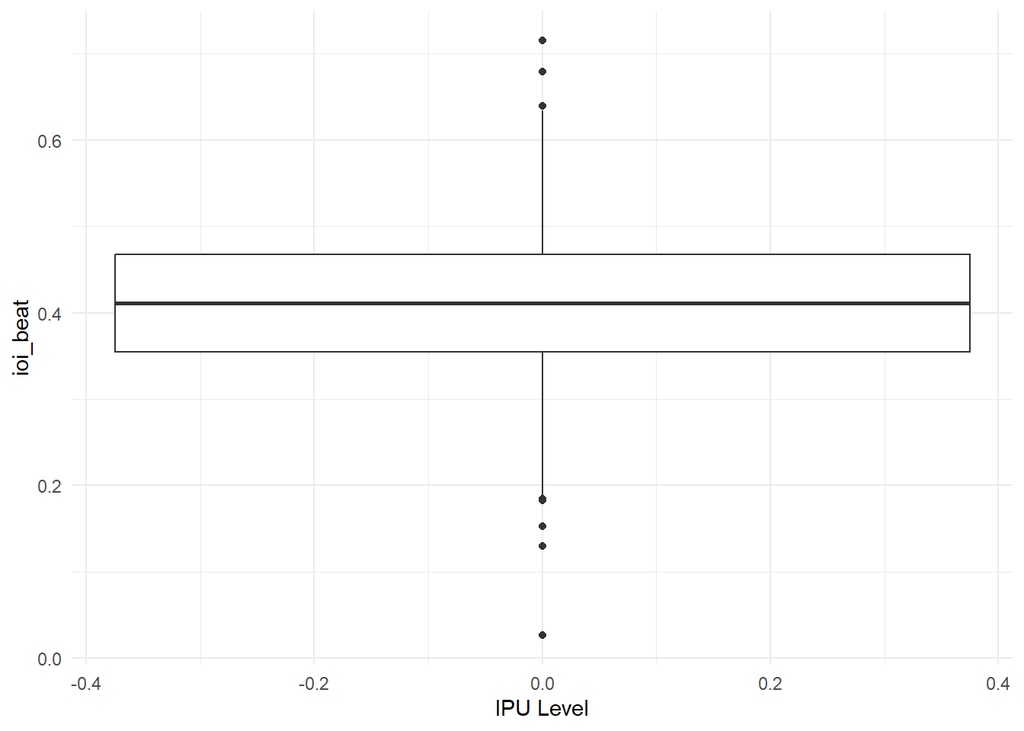

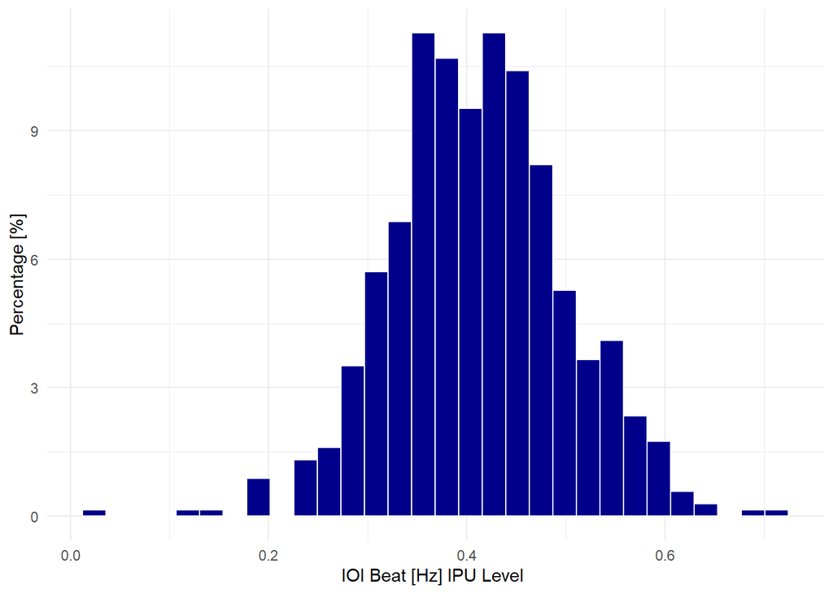

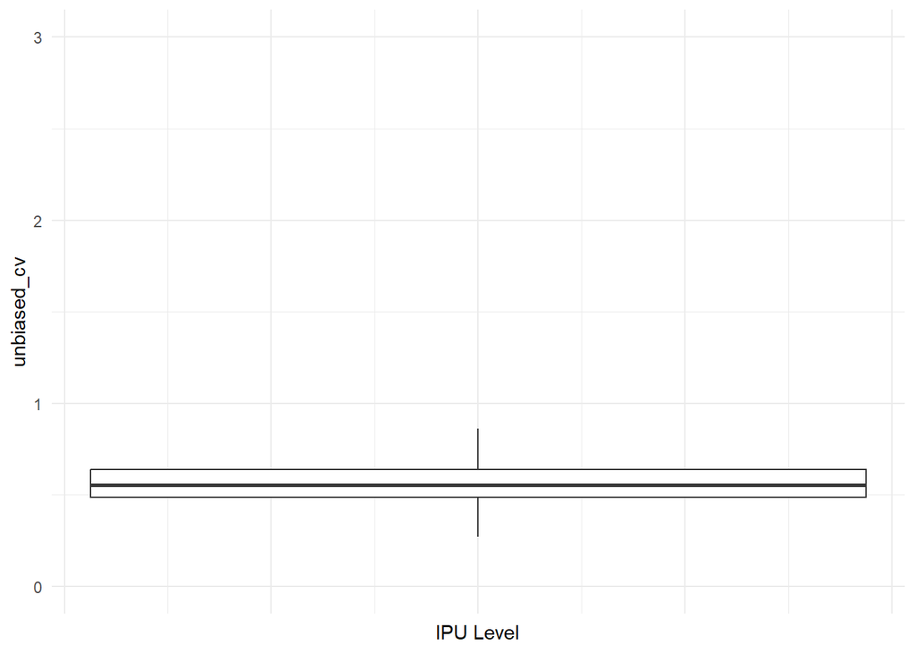

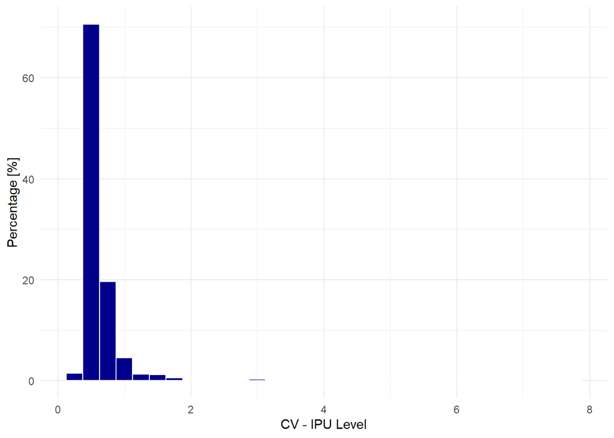

Now we plot IOI Beat [Hz] for the IPU Level per language and per language family.

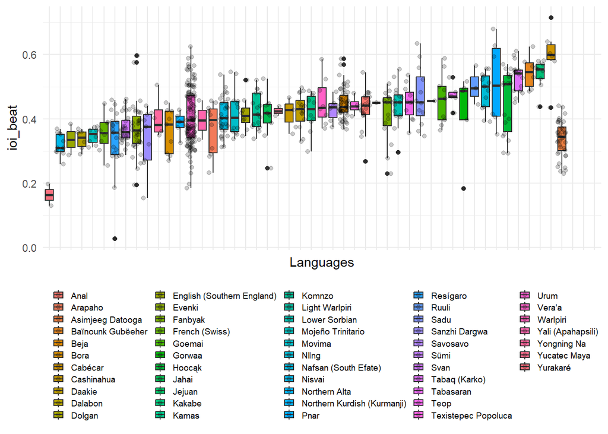

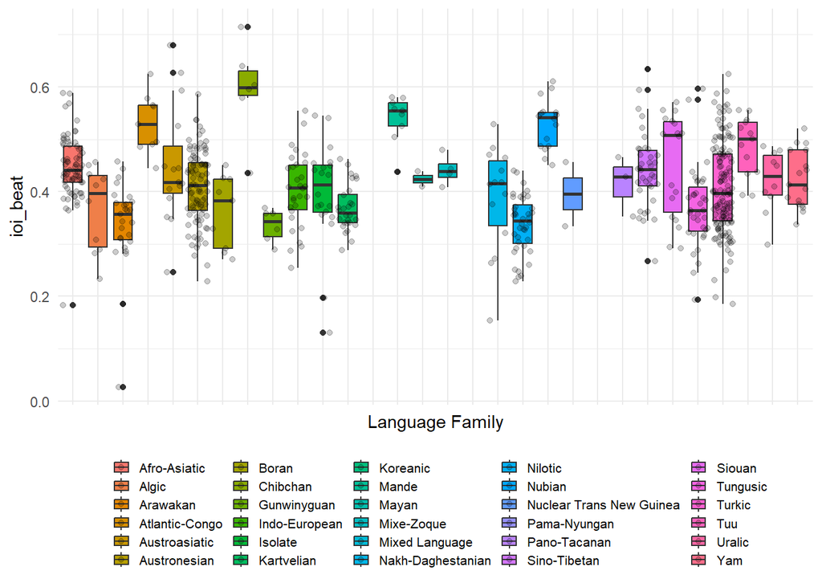

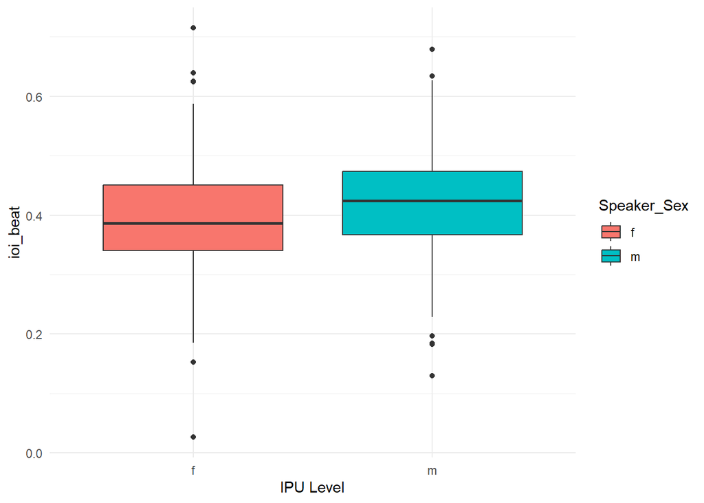

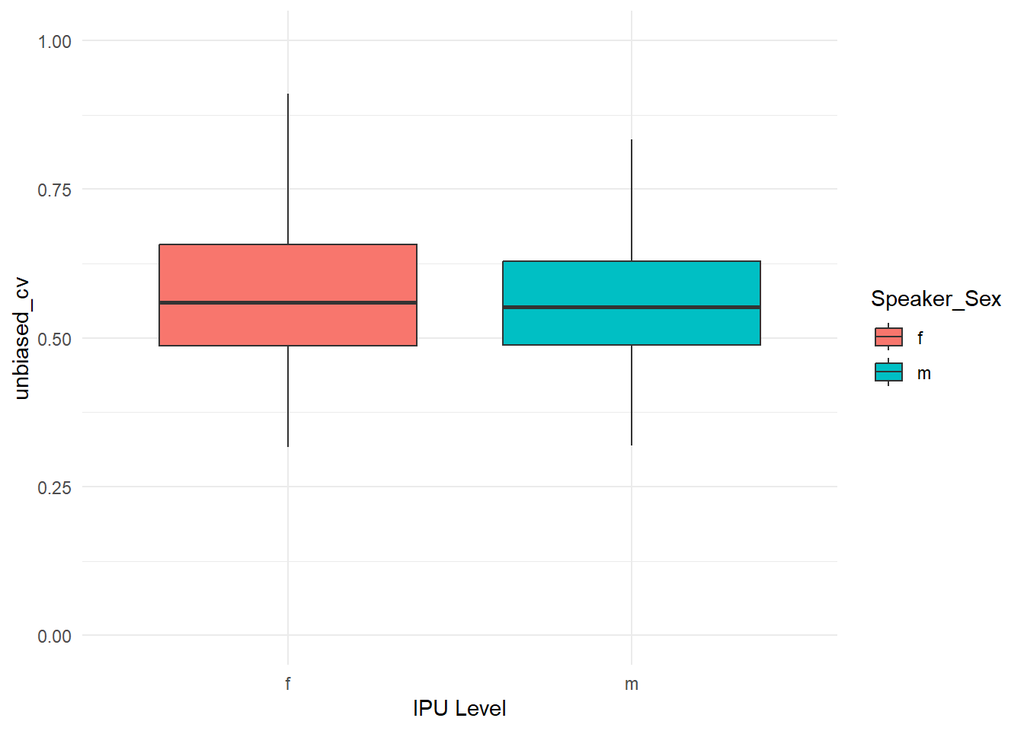

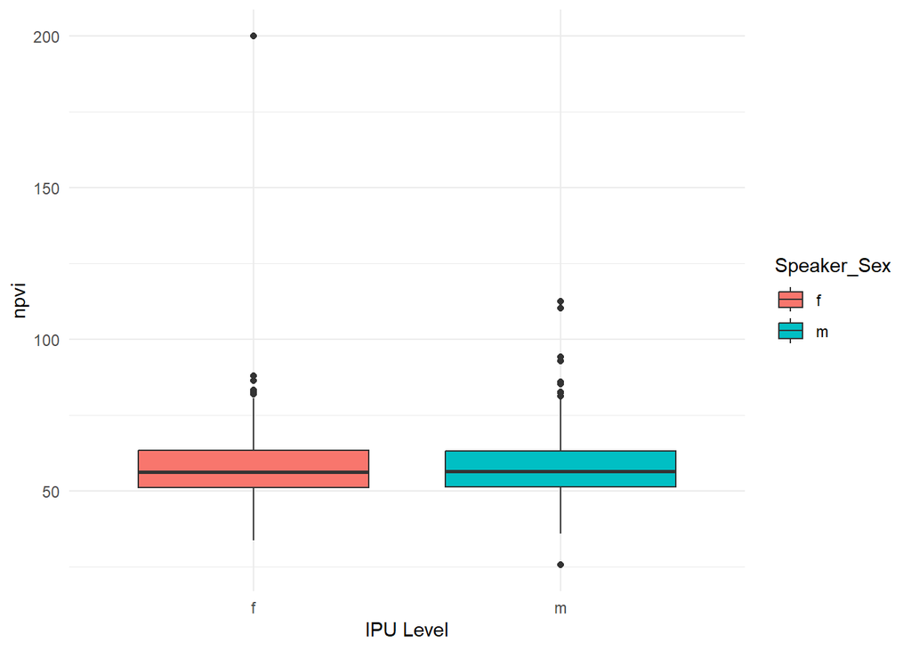

We also want to visualize the effect of age on the IOI Beat on the IPU Level.

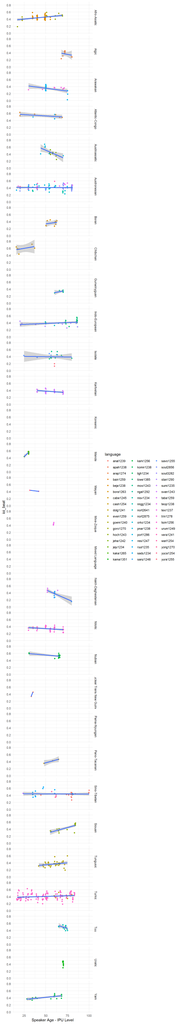

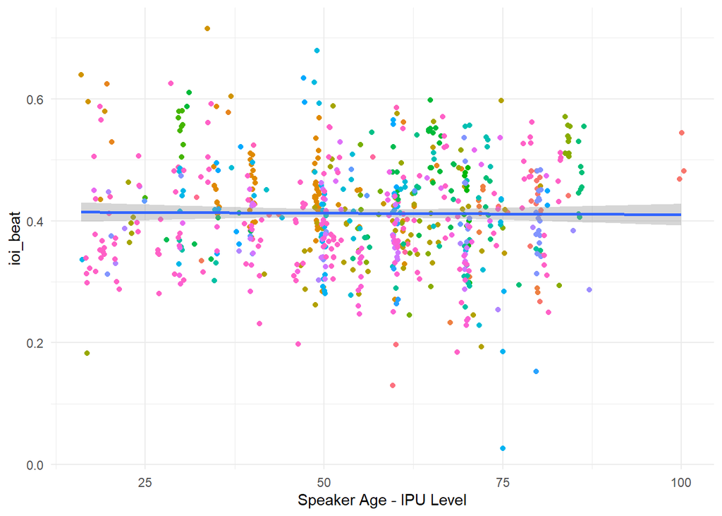

### Word Level

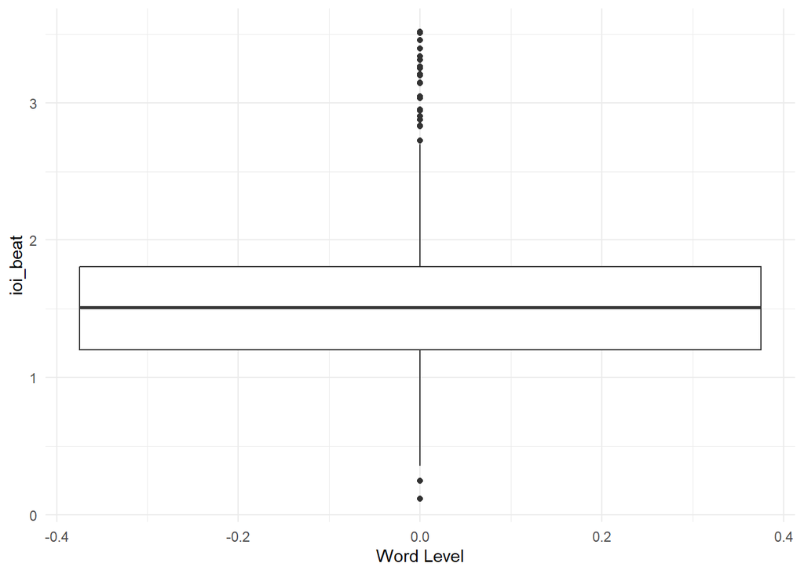

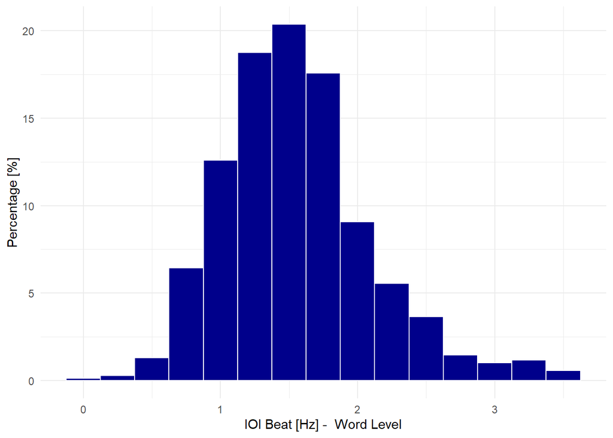

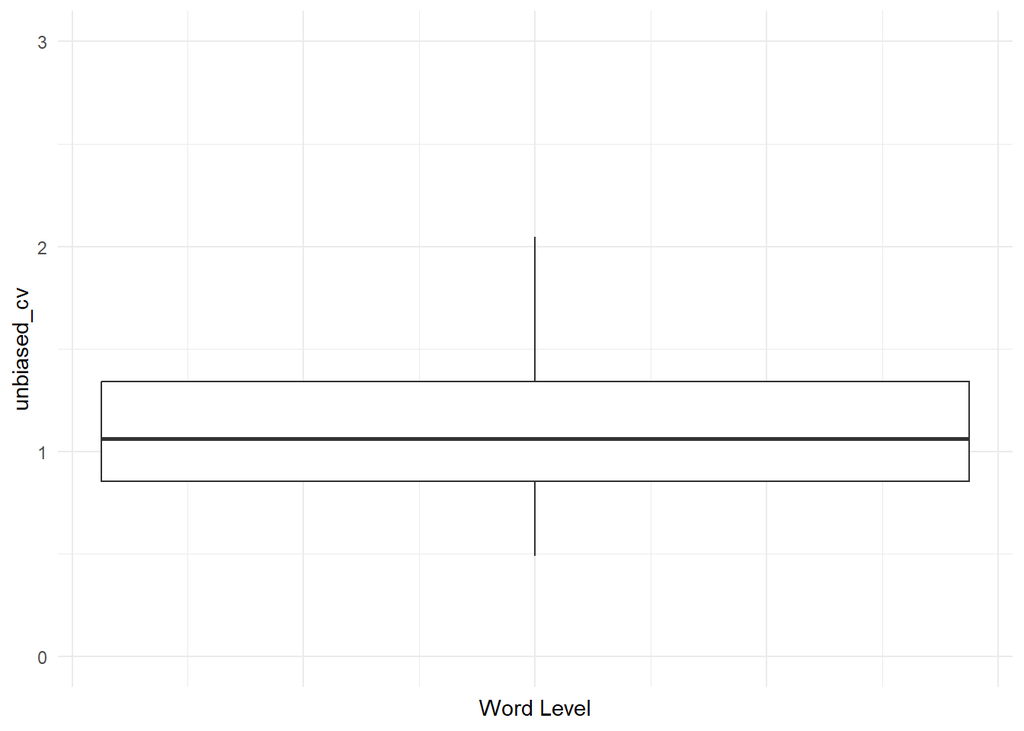

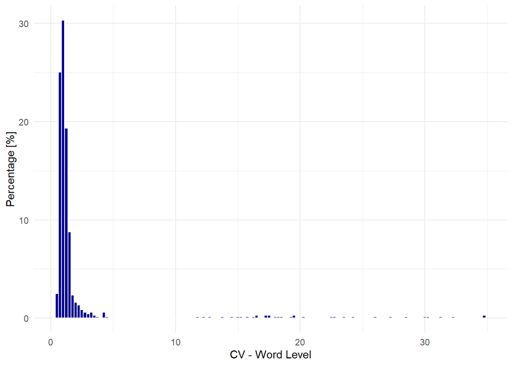

Now we plot the IOI Beat [Hz] for the word level per language and per language family.

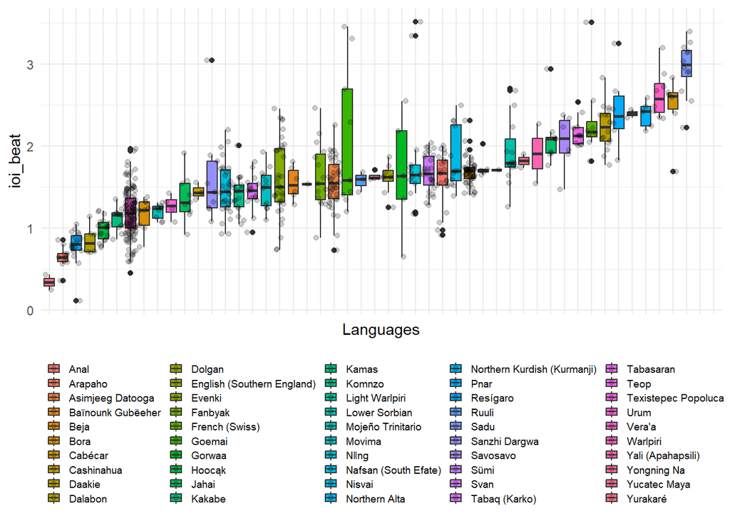

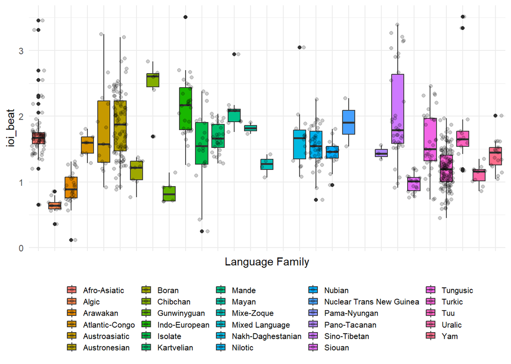

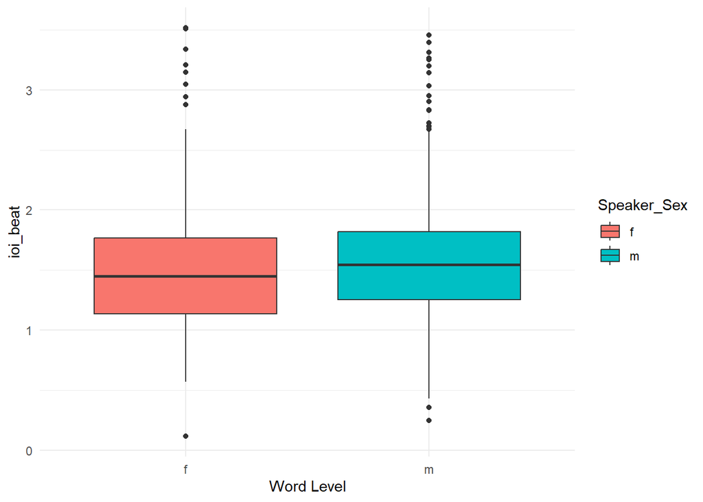

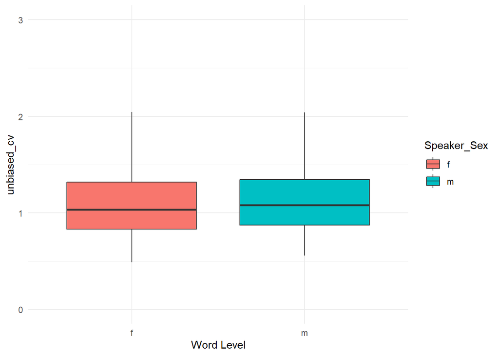

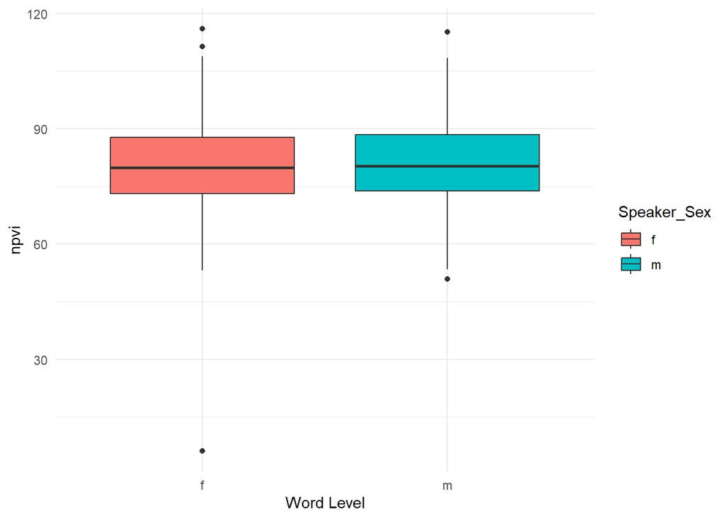

We also want to visualize the effect of age on the IOI Beat on the Word Level.

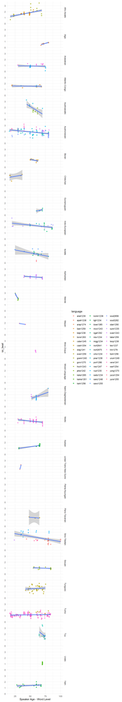

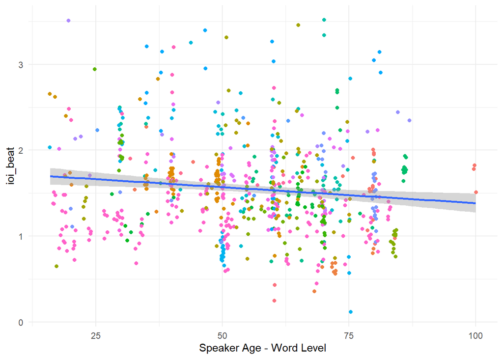

# Analysis Ideas

# Interpretations/Thoughts

Interestingly, individual sequence rhythms pooled from all language seem to follow normal distributions on the ipu level as well as the word level though, this hints at underlying biomechanical/perceptual reasons for rhythms in that range.

Do these in fact fit with perceptual “optimal rates” found for humans?

Can we say something about outliers?

What about the slight sex differences? Why are men faster? Is that significant? What is the effect size?

Can we model what has the biggest effect on the rhythm of an individual? Is it language/language family/sex/age? Is there a difference between the model for ipu and word level? I would expect the model to show a bigger importance of “biological parameters” such as sex and age for the ipu level, while it should be stronger influenced by language and language family on the word level.